# A spatial model of CoVID-19 transmission in England and Wales: early spread and peak timing

Leon Danon

17/02/2020

*Last updated 13/02/2020*

Leon Danon (1), Ellen Brooks-Pollock (2), Mick Bailey (3), Matt Keeling (4)

1. L.Danon@exeter.ac.uk, University of Exeter
2. Ellen.Brooks-Pollock@bristol.ac.uk, University of Bristol
3. Mick.Bailey@bristol.ac.uk, University of Bristol
4. M.J.Keeling@warwick.ac.uk University of Warwick

**Note: this is preliminary analysis and has not yet been peer-reviewed.**

Full preprint is here: https://www.medrxiv.org/content/10.1101/2020.02.12.20022566v1

### Background

An outbreak of a novel coronavirus, named CoVID-19, was first reported in China on 31 December 2019. As of 9 February 2020, cases have been reported in 25 countries, including probable cases of human-to-human transmission in England.

### Methods

We adapted an existing national-scale metapopulation model to capture the spread of CoVID-19 in England and Wales. We used 2011 census data to capture population sizes and population movement, together with parameter estimates from the current outbreak in China.

### Results

We predict that a CoVID-19 outbreak will peak 126 to 147 days (~4 months) after the start of person-to-person transmission in England and Wales in the absence of controls, assuming biological parameters remain unchanged. Therefore, if person-to-person transmission persists from February, we predict the epidemic peak would occur in June, with some regional variation (see Figure 1). The starting location has minimal impact on peak timing, and model stochasticity varies peak timing by 10 days. Incorporating realistic parameter uncertainty leads to estimates of peak time ranging from 78 days to 241 days after person-to-person transmission has been established. Seasonal changes in transmission rate substantially impact the timing and size of the epidemic peak, as well as the total attack rate (see Figure 2).

### Discussion

We provide initial estimates of the potential course of CoVID-19 in England and Wales in the absence of control measures. These results can be refined with improved estimates of epidemiological parameters, and permit investigation of control measures and cost effectiveness analyses. Seasonal changes in transmission rate could shift the timing of the peak into winter months, which will have important implications for health-care capacity planning.

### Limitations

The model includes a number of assumptions which should be considered alongside the results.

- We assume *uncontrolled spread*, with no measures to mitigate transmission and no change in behaviour during the course of the epidemic. In practice, as the epidemic starts spreading in England and Wales there will be control measures in place as well as a likely systematic change in behaviour.
- Parameter estimates from China have been used; it is likely that transmission will be different in England and Wales.
- We assume “mean-field mixing” within each ward, i.e. that mixing patterns are not contingent on age or other factors. This means that the estimates for the total number of people infected during the epidemic are likely to be less reliable.
- The model in its current form predicts the total number of infections in the community rather than diagnosed cases and we did not include morbidity, mortality and the treatment of cases.

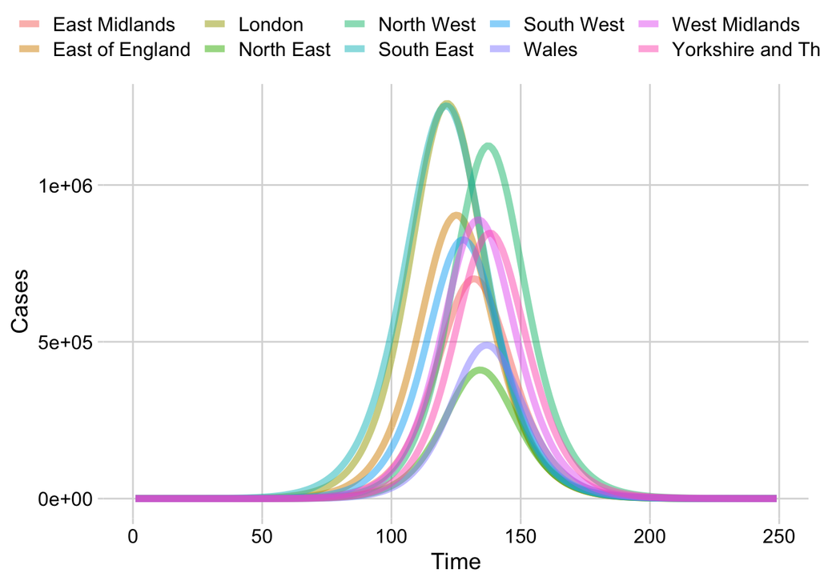

Figure 1: Predicted epidemic curves for a CoVID-19 outbreak broken down by region for England and Wales.

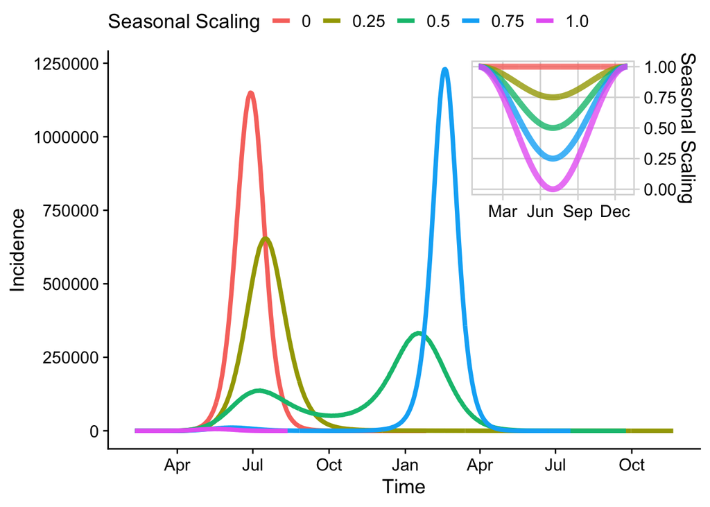

Figure 2: Effect of seasonal changes in transmission rate, assuming a reduction in transmission over the summer. (main panel) Incidence over time, for different values of seasonal scaling. (inset) Variation of scaling term for the course of one year, with transmission being at its lowest in July.